# slide_deck_template slides

# (Ford go bike report for february 2019) ## by (Michel Ashraf)

## Investigation Overview

In this investigation, I will present the difference and the relation between our 2 types of memebrs (Subscribers and Customers)Aswell as the peak days,peak hours, the bike trip durations.

## Dataset Overview

This dataset is about the Ford GoBike's trip data for public containing bike rides on February 2019.There are 16 features in this dataset some of them are related to the members like their born year,gender. Others are related to the bike trips itself like the trip durations its start date,start station... etc

## (Ratio between type of members visualization)

> we can see that Most of the members are Subscribers with a 91.7% compared to 8.3% of Customers

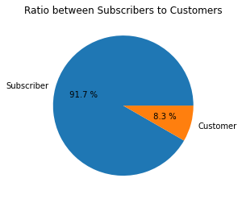

```python
data=[df["user_type"].value_counts()[0],df["user_type"].value_counts()[1]]
labels = ['Subscriber', 'Customer']
plt.pie(data,labels=labels,autopct ='% 1.1f %%')
plt.title('Ratio between Subscribers to Customers')
plt.show()
```

## (The difference between the age between the Customers and the Subscribers)

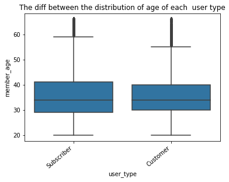

```python
boxplot(df,'user_type','member_age','The diff between the distribution of age of each  user type');
```

## (The daily usage of the Subscribers and the Customers)

we can see that Sunday and Saturday are the least 2 days in terms of bike usage weather it was for a Subscriber or a Customer (maybe because they are weekends)

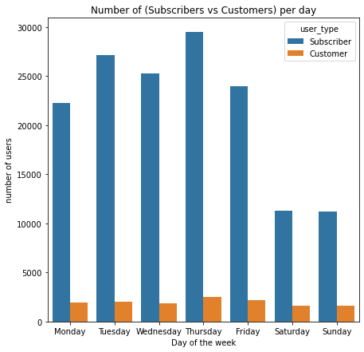

```python
plt.figure(figsize = [7, 7]);
countplot1('rental_day','user_type','Number of (Subscribers vs Customers) per day','Day of the week','number of users');
```

# (The hourly usage of the Subscribers and the Customers)

8 am and 5 pm are two peek hours weather it was for a subscriber or a user

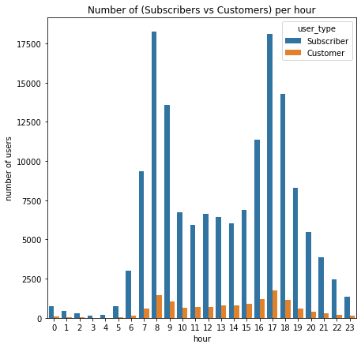

```python
plt.figure(figsize = [7, 7]);
countplot1('rental_hour','user_type','Number of (Subscribers vs Customers) per hour','hour','number of users');
```

# Lets see the relationship between Subscribers and Customers interms of the age vs duration per mins of their trips

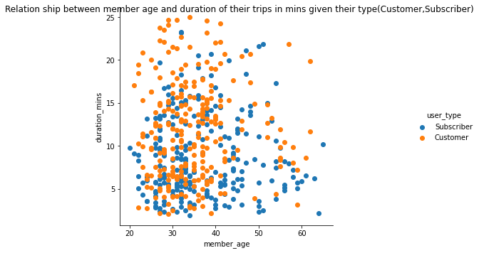

```python
#we will take a 500 sample of our data set
#250 of them are Subs and 250 are Customers

s0 = df.user_type[df.user_type.eq('Customer')].sample(250).index
s1 = df.user_type[df.user_type.eq('Subscriber')].sample(250).index

df_sample = df.loc[s0.union(s1)]
g = sb.FacetGrid(data = df_sample, hue = 'user_type', size = 5)
g.map(plt.scatter, 'member_age', 'duration_mins')
g.add_legend()
g.fig.suptitle('Relation ship between member age and duration of their trips in mins given their type(Customer,Subscriber)');
```

# The days with the highest trip durations in general

we can see Sunday and Saturday are the most 2 days with with trips durations(maybe because they are weekends)

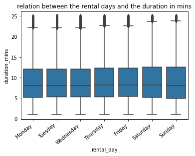

```python
boxplot(df,'rental_day','duration_mins','relation between the rental days and the duration in mins');
```

# # The hours with the highest trip durations in general

5 pm ,8 am , and its also weird to see 3 am as one of the most 3 hours with trip durations

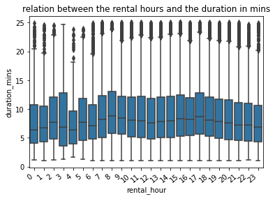

```python
boxplot(df,'rental_hour','duration_mins','relation between the rental hours and the duration in mins');
```

# Days with most rides(peak days)

as we can see Thursday and Tuesday are the most 2 days with rents

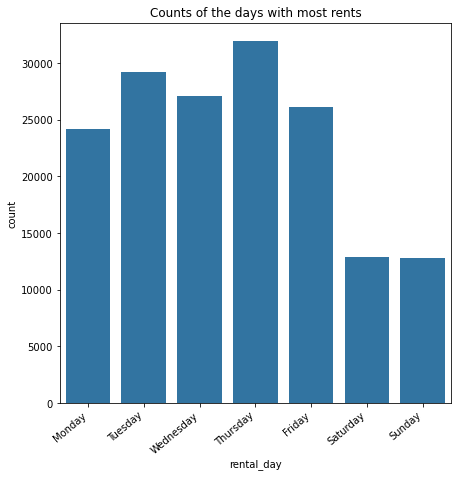

```python
plt.figure(figsize = [7, 7]);
countplot('rental_day','Counts of the days with most rents');
```

# Hours with most rides(peak hours)

The almost two equaly peek hours are either 8 am in the morning or 5 pm

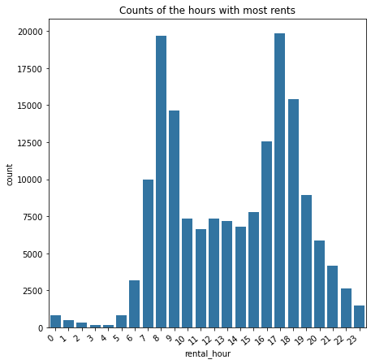

```python
plt.figure(figsize = [7, 7]);
countplot('rental_hour','Counts of the hours with most rents');
```